# Lab 6.1 - Visualizing Spatial Data

Trey Tipton

Fall 2022

The late comedian [Mitch Hedberg](https://en.wikipedia.org/wiki/Mitch_Hedberg) famously joked that “La Quinta” is Spanish for “next to Denny’s”. In this lab exercise, we explore the accuracy of his claim that [Denny’s](https://www.dennys.com/), a casual diner chain that is open 24 hours, is actually co-located with [La Quinta Inn and Suites](http://www.lq.com/), a hotel chain. This lab is inspired by a blog post by John Reiser entitled [Mitch Hedberg and GIS](http://njgeo.org/2014/01/30/mitch-hedberg-and-gis/).

## Loading the Dataset

We use three datasets, all stored in [./data](https://cs.calvin.edu/courses/info/601/06wrangling/lab/data/.):

- `dennys` — The locations of all Denny’s restaurants:
  - *Scraped* from [All Denny’s Locations](https://locations.dennys.com/)
  - Described here: [Locations of Denny’s restaurants](https://rstudio-education.github.io/dsbox/reference/dennys.html)
- `laquinta` — The locations of all La Quinta hotels:
  - *Scraped* from [La Quinta Locations](https://www.wyndhamhotels.com/laquinta/locations)
  - Described here: [Locations of La Quinta Inn motels](https://rstudio-education.github.io/dsbox/reference/laquinta.html)
- `states` — The names of all the US states, including DC, plus some additional information.

```r
dennys <- read_rds("data/dennys.rds")
laquinta <- read_rds("data/laquinta.rds")
states <- read_csv("data/states.csv", col_types = cols(
  name = col_character(),
  abbreviation = col_character(),
  area = col_double()
))
```

The dennys and laquinta datasets contain the address, city, state, zip code, and the coordinates of all of the locations in the world. The states dataset contains the name and abbreviations of all of the U.S. states as well as their area. The dennys dataset has 1643 observations (locations), laquinta 909, and the states 51 (including DC).

## Focusing on US Locations

We limit our analysis to Denny”s and La Quinta locations in the United States.

Are there any Denny’s or La Quinta locations that are outside the US? Answer this by filtering for observations where `state` is not in `states$abbreviation`. Here, the `%in%` operator matches the states listed in the `state` variable to those listed in the `states$abbreviation` vector. The `!` operator means **not**:

```r
dennys %>%
  filter(!(state %in% states$abbreviation))
```

```
# A tibble: 0 × 6
# … with 6 variables: address <chr>, city <chr>, state <chr>, zip <chr>,
#   longitude <dbl>, latitude <dbl>
```

```r
laquinta <- laquinta %>%
  filter((state %in% states$abbreviation))
```

There are not any observations outside the U.S. for Denny’s, there are 14 outside of the U.S. for La Quinta. I changed the code above to remove those 14 locations from the dataset.

Going forward we will work with the data from the United States only, so you can redefine `dennys` and `laquinta` to include only US locations. Include an indication of how many Denny’s and La Quinta records are filtered out because they are not in the US.

## Computing Frequencies

We now compute some density statistics for the two franchises.

### By State

Compute which states have the most and fewest Denny’s locations. Do the same for La Quinta. Describe the results and discuss whether there’s anything interesting about them.

```r
dennys %>%
  count(state, sort = TRUE)
```

```
# A tibble: 51 × 2
   state     n
   <chr> <int>
 1 CA      403
 2 TX      200
 3 FL      140
 4 AZ       83
 5 IL       56
 6 NY       56
 7 WA       49
 8 OH       44
 9 MO       42
10 PA       40
# … with 41 more rows
```

California has the most Denny’s locations and Delaware has the fewest. It makes sense that California has the most locations because of its population and area, but Delaware only having one location is somewhat interesting, even with how small it is.

```r
laquinta %>%
  count(state, sort = TRUE)
```

```
# A tibble: 48 × 2
   state     n
   <chr> <int>
 1 TX      237
 2 FL       74
 3 CA       56
 4 GA       41
 5 TN       30
 6 OK       29
 7 LA       28
 8 CO       27
 9 NM       19
10 NY       19
# … with 38 more rows
```

```r
states %>%
  filter(!(abbreviation %in% laquinta$state))
```

```
# A tibble: 3 × 3
  name                 abbreviation    area
  <chr>                <chr>          <dbl>
1 Delaware             DE            2489.
2 Hawaii               HI           10932.
3 District of Columbia DC              68.3
```

Texas has the most La Quinta locations and Delaware, Hawaii, and DC have no locations. Again, it makes sense that Texas has a lot of locations, but it is surprising that California has so little in comparison, and that there are states without locations at all.

### By Area

Compute which states have the most Denny’s locations *per thousand square miles*. Do the same for La Quinta. Describe the results and discuss whether there’s anything interesting about them. *Note*: to do this, you’ll need to *look up* the area of the states in the `states` dataset. Start with the table of counts by state that you just computed above and then *join* it with the table that has the area of each state. The states’ areas are given in square miles; make a new column for the result of the unit conversion.

```r
dennys_area <- left_join(dennys, states, by = c('state' = 'abbreviation'))

dennys_area %>%
  count(state, wt = 1000/area, sort = TRUE)
```

```
# A tibble: 51 × 2
   state      n
   <chr>  <dbl>
 1 DC    29.3
 2 RI     3.24
 3 CA     2.46
 4 CT     2.16
 5 FL     2.13
 6 MD     2.10
 7 NJ     1.15
 8 NY     1.03
 9 IN     1.02
10 OH     0.982
# … with 41 more rows
```

```r
laquinta_area <- left_join(laquinta, states, by = c('state' = 'abbreviation'))

laquinta_area %>%
  count(state, wt = 1000/area, sort = TRUE)
```

```
# A tibble: 48 × 2
   state     n
   <chr> <dbl>
 1 RI    1.29
 2 FL    1.13
 3 CT    1.08
 4 MD    1.05
 5 TX    0.882
 6 TN    0.712
 7 GA    0.690
 8 NJ    0.573
 9 MA    0.568
10 LA    0.535
# … with 38 more rows
```

It is interesting that when accounting for the square mileage, per 1000 square miles, Rhode Island has the most La Quinta locations and also the most Denny’s locations with the exception of DC.

## Plotting Locations

Finally, we plot the locations (latitude and longitude) of both establishments.

To do this, we’ll put the two datasets together into a single data frame. First, we’ll add an identifier variable called `establishment` to distinguish rows from the two datasets, and then we’ll bind them with the `bind_rows` function (n.b., this binding works because the two tables have the same columns):

```r
dn_lq <- bind_rows(
  dennys %>% mutate(establishment = "Denny's"),
  laquinta %>% mutate(establishment = "La Quinta"),
)
```

Plot the locations of the two establishments using a scatter plot, and color the points by the establishment type. *Note*: the latitude is plotted on the x-axis and the longitude on the y-axis.

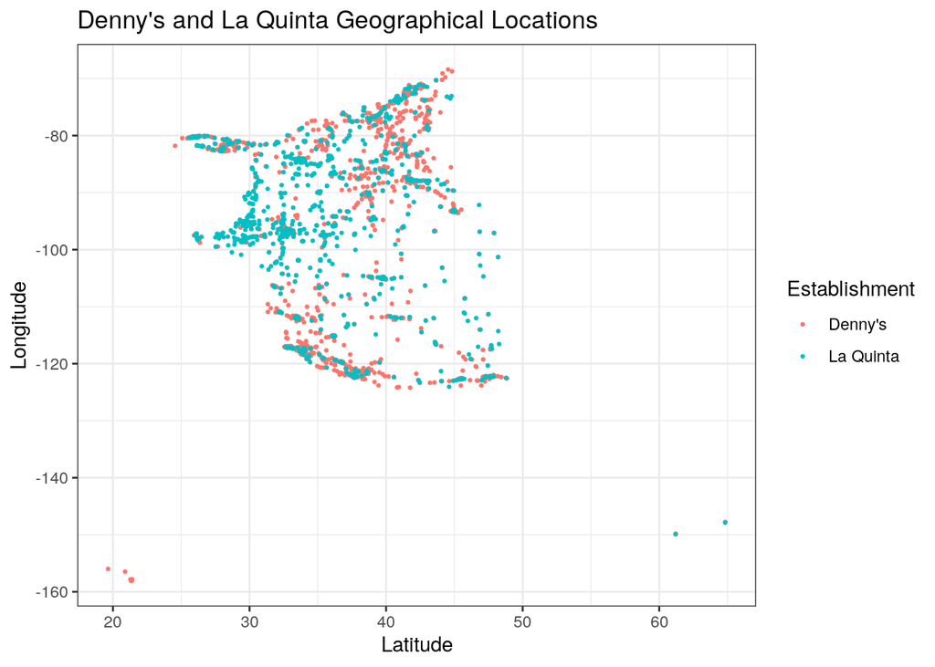

```r
dn_lq %>%
  ggplot() +
  aes(x = latitude, y = longitude, color = establishment) +
  geom_point(size = .5) +
  labs(x = "Latitude", y = 'Longitude', title = "Denny's and La Quinta Geographical Locations", color = 'Establishment')
```

## Drawing Conclusions

In conclusion, do Denny’s restaurants and La Quinta motels appear, visually, to be co-located?

Overall, it does not appear that Denny’s and La Quinta motels appear to be co-located; there are too many spots that have one and not the other for me to say that they are co-located. However, there are several areas that contain both.